# Notebook 3 - Data Analysis, Model Generation and Evalaution

- Basic analysis of given data, Visualization of features with respect to essay scores.
- Creation of models - Neural Net, Random Forest and Linear Regression for automatic essay scoring.
- Evaluation of the models using Quadrtic Weighted Kappa and Spearman's Rho

### Importing all the libraries needed for this notebook:

```python
import pandas as pd
import numpy as np
import time
import matplotlib.pyplot as plt
%matplotlib inline
```

### Loading the data from the given data set, encoding in latin-1:

```python
df = pd.read_csv('essay_scoring.csv', encoding='latin-1')
```

```python
print(df.shape)
df.head()
```

```
(12978, 6)
```

|  | essay_id | essay_set | essay | rater1_domain1 | rater2_domain1 | domain1_score |
| --- | --- | --- | --- | --- | --- | --- |
| 0 | 1 | 1 | Dear local newspaper, I think effects computer... | 4.0 | 4.0 | 8.0 |
| 1 | 2 | 1 | Dear @CAPS1 @CAPS2, I believe that using compu... | 5.0 | 4.0 | 9.0 |
| 2 | 3 | 1 | Dear, @CAPS1 @CAPS2 @CAPS3 More and more peopl... | 4.0 | 3.0 | 7.0 |
| 3 | 4 | 1 | Dear Local Newspaper, @CAPS1 I have found that... | 5.0 | 5.0 | 10.0 |
| 4 | 5 | 1 | Dear @LOCATION1, I know having computers has a... | 4.0 | 4.0 | 8.0 |

```python
df = df.drop('essay_id',1)
df = df.drop('essay_set',1)
df = df.drop('rater1_domain1',1)
df = df.drop('rater2_domain1',1)
```

```python
df.describe()
```

|  | domain1_score |
| --- | --- |
| count | 12977.000000 |
| mean | 6.799723 |
| std | 8.970558 |
| min | 0.000000 |
| 25% | 2.000000 |
| 50% | 3.000000 |
| 75% | 8.000000 |
| max | 60.000000 |

### Removing null values:

```python
# Checking for null values in the dataset.
print("Nulls in dataset: {0} => {1}".format(df.columns.values, df.isnull().any().values))
```

```
Nulls in dataset: ['essay' 'domain1_score'] => [False  True]
```

```python
# Removing null values in the dataset.
df = df[np.isfinite(df['domain1_score'])]
```

```python
df.shape
```

```
(12977, 2)
```

```python
print("Nulls in dataset: {0} => {1}".format(df.columns.values, df.isnull().any().values))
```

```
Nulls in dataset: ['essay' 'domain1_score'] => [False False]
```

### Loading file to extract normalized grades for essays:

```python
score_df = pd.read_csv('data.csv')
```

```python
score_df = score_df.drop('Unnamed: 0',axis=1)
score_df = score_df.drop('essay_set',1)
score_df = score_df.drop('essay',1)
```

```python
score_df.head()
```

|  | domain1_score |
| --- | --- |
| 0 | 6.0 |
| 1 | 7.0 |
| 2 | 5.0 |
| 3 | 8.0 |
| 4 | 6.0 |

### Loading file to access features for given data:

```python
# Loading the feature generated data and removing unwanted columns.
features_df = pd.read_csv('features.csv')
features_df = features_df.drop('Unnamed: 0',axis=1)
```

```python
features_df.head()
```

|  | adjective_count | adverb_count | average_word_length | long_word_count | noun_count | sentences_count | spelling_error_count | verb_count | vocab_count | word_count | word_to_sentence_ratio |
| --- | --- | --- | --- | --- | --- | --- | --- | --- | --- | --- | --- |
| 0 | 28 | 11 | 5.58 | 45 | 71 | 16 | 16 | 38 | 29.482659 | 168 | 10.19 |
| 1 | 23 | 10 | 5.67 | 62 | 96 | 20 | 23 | 54 | 20.220089 | 226 | 10.80 |
| 2 | 17 | 2 | 6.05 | 51 | 72 | 14 | 4 | 36 | 15.286432 | 139 | 9.43 |
| 3 | 41 | 13 | 6.23 | 79 | 123 | 27 | 41 | 56 | 30.737705 | 301 | 9.63 |
| 4 | 25 | 13 | 5.94 | 69 | 113 | 30 | 20 | 46 | 20.258941 | 226 | 7.40 |

## Features Visualization

### The following features for each essay will be used for visualization : -

- Word count : Number of words
- Sentence count : Number of sentences
- Long words count : Number of words with length greater than 6 per
- Spelling error count : Number of spelling mistakes
- Words to sentences ratio : To find if the sentences are short and simple or long and complex.
- Vocabulary richness count : To find the vocabulary used
- Noun Count : Number of nouns used

#### Word Count v/s Essay Grade

```
Text(0.5,1,'Word Count v/s Essay Grade')
```

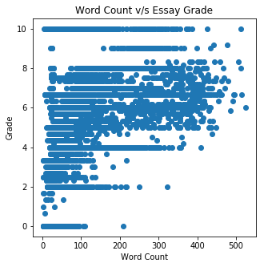

```python
fig, dig1 = plt.subplots(1, 1, figsize=(5, 5))

dig1.scatter(features_df['word_count'], score_df['domain1_score'])
dig1.set_ylabel('Grade')
dig1.set_xlabel('Word Count')
dig1.set_title('Word Count v/s Essay Grade')
```

The word counts in general have a positive correlation with the essay score.

#### Vocabulary Richness v/s Essay Grade

```
Text(0.5,1,'Vocabulary richness v/s Essay Grade')
```

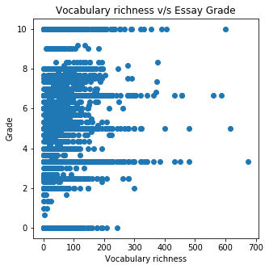

```python
fig, dig2 = plt.subplots(1, 1, figsize=(5, 5))

dig2.scatter(features_df['vocab_count'], score_df['domain1_score'])
dig2.set_ylabel('Grade')
dig2.set_xlabel('Vocabulary richness')
dig2.set_title('Vocabulary richness v/s Essay Grade')
```

More vocabulary means more variety of words used which should give a higher score.  
There is a moderately positive correlation between the vocabulary richness and essay score.

#### Spelling Error Count v/s Essay Grade

```
Text(0.5,1,'Spelling Error Count v/s Essay Grade')
```

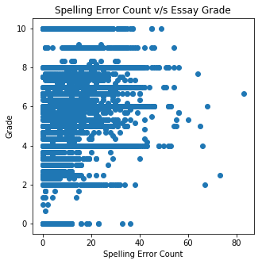

```python
fig, dig3 = plt.subplots(1, 1, figsize=(5, 5))

dig3.scatter(features_df['spelling_error_count'], score_df['domain1_score'])
dig3.set_ylabel('Grade')
dig3.set_xlabel('Spelling Error Count')
dig3.set_title('Spelling Error Count v/s Essay Grade')
```

It can be observed here that even essays with a large number of spelling mistakes can receive a higher grade.  
The graders probably consider the overall essay more important than the spelling errors.

#### Sentences Count v/s Essay Grade

```
Text(0.5,1,'Sentences Count v/s Essay Grade')
```

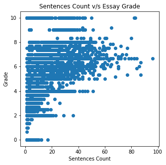

```python
fig, dig4 = plt.subplots(1, 1, figsize=(5, 5))

dig4.scatter(features_df['sentences_count'], score_df['domain1_score'])
dig4.set_ylabel('Grade')
dig4.set_xlabel('Sentences Count')
dig4.set_title('Sentences Count v/s Essay Grade')
```

The sentence counts in general have a positive correlation with the essay score.

#### Long Words Count v/s Essay Grade

```
Text(0.5,1,'Long words count v/s Essay Grade')
```

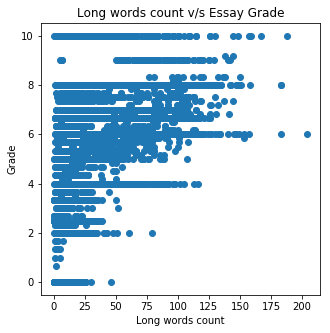

```python
fig, dig5 = plt.subplots(1, 1, figsize=(5, 5))

dig5.scatter(features_df['long_word_count'], score_df['domain1_score'])
dig5.set_ylabel('Grade')
dig5.set_xlabel('Long words count')
dig5.set_title('Long words count v/s Essay Grade')
```

Higher the number of long words used higher is the essay score.

#### Noun Count v/s Essay Grade

```
Text(0.5,1,'Noun count v/s Essay Grade')
```

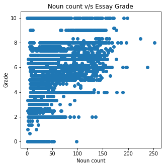

```python
fig, dig6 = plt.subplots(1, 1, figsize=(5, 5))

dig6.scatter(features_df['noun_count'], score_df['domain1_score'])
dig6.set_ylabel('Grade')
dig6.set_xlabel('Noun count')
dig6.set_title('Noun count v/s Essay Grade')
```

#### Word to sentence ratio v/s Essay Grade

```
Text(0.5,1,'Word to sentence ratio v/s Essay Grade')
```

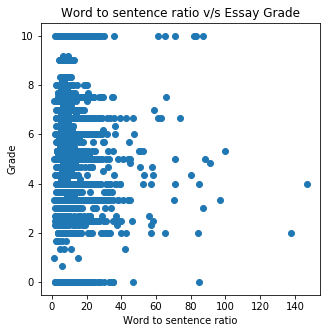

```python
fig, dig7 = plt.subplots(1, 1, figsize=(5, 5))

dig7.scatter(features_df['word_to_sentence_ratio'], score_df['domain1_score'])
dig7.set_ylabel('Grade')
dig7.set_xlabel('Word to sentence ratio')
dig7.set_title('Word to sentence ratio v/s Essay Grade')
```

In most cases, short and simple sentences are better than long and complex.

## Following models are created:

- Neural Net
- Random Forest
- Linear Regression

I have used 5-fold cross validation to train and test my model rigorously.  
This was done to avoid overfitting.

```python
X = features_df
y = score_df['domain1_score']
```

```python
from sklearn.preprocessing import StandardScaler
from sklearn.model_selection import KFold
from sklearn import cross_validation
from sklearn.neural_network import MLPClassifier
from sklearn.linear_model import LinearRegression
from sklearn.ensemble import RandomForestRegressor

from functions import quadratic_weighted_kappa as qwk
from scipy.stats import spearmanr

# Using 5 fold cross validation
cv = cross_validation.KFold(len(X), n_folds=5,shuffle=True)

qwk_neural_net = []
qwk_random_forest = []
qwk_linear_regression = []

spearman_nn_list = []
spearman_rf_list = []
spearman_lm_list = []

for traincv, testcv in cv:
    X_test, X_train, y_test, y_train = X.iloc[testcv], X.iloc[traincv], y.iloc[testcv], y.iloc[traincv]

    # Scaling the data
    scaler = StandardScaler()
    scaler.fit(X_train)
    X_train = scaler.transform(X_train)
    X_test = scaler.transform(X_test)

    # Creating the models

    # Neural Net
    mlp = MLPClassifier(solver='lbfgs', alpha=1e-5, hidden_layer_sizes=(10, 10),
                       activation='tanh', max_iter=2000, batch_size = 50)


    mlp.fit(X_train, y_train.astype(int))

    predictions = mlp.predict(X_test)
    y_pred_nn = predictions.tolist()

    y_test_nn = y_test.astype(int)
    y_test_nn = y_test_nn.tolist()

    y_test = y_test.tolist()

    # Linear Regression
    learning_model =  LinearRegression(normalize=True)
    learning_model.fit(X_train, y_train)

    predictions_lm = learning_model.predict(X_test)
    y_pred_lm = predictions_lm.tolist()

    # Random Forest
    rf = RandomForestRegressor(n_estimators= 1000, random_state=42)
    rf.fit(X_train, y_train);

    predictions_rf = rf.predict(X_test)
    y_pred_rf = predictions_rf.tolist()

    # Quadratic Weighted Kappa
    qwk_neural_net.append( qwk(y_pred_nn, y_test) )
    qwk_random_forest.append( qwk(y_pred_rf, y_test) )
    qwk_linear_regression.append( qwk(y_pred_lm, y_test) )

    # Spearman's Rho
    spearman_nn = spearmanr(y_test, y_pred_nn)
    spearman_rf = spearmanr(y_test, y_pred_rf)
    spearman_lm = spearmanr(y_test, y_pred_lm)

    spearman_nn_list.append(spearman_nn[0])
    spearman_rf_list.append(spearman_rf[0])
    spearman_lm_list.append(spearman_lm[0])
```

## Calculating Mean Quadratic Kappa for the 3 models:

I have used Quadratic weighted kappa(qwk) as the evaluation metric for the models created.  
This metric usually varies from 0 (random agreement) to 1 (complete agreement).  
A negative value indicates the the agreement between raters is less than that expected by chance.

The qwk is calculated between the resolved score between the raters and the predicted scores for the essays.

```python
np.mean(qwk_neural_net)
```

```
0.6196178469037482
```

```python
np.mean(qwk_random_forest)
```

```
0.630806541949549
```

```python
np.mean(qwk_linear_regression)
```

```
0.35204743811239847
```

#### The Kappa value can be interpreted as follows:

Value of K | Strength of agreement

0.0 - 0.20 | Poor  
0.21 - .40 | Fair  
0.41 - .60 | Moderate  
0.61 - .80 | Good  
0.81 - 1.0 | Very good

- The model that performs the best is the random forest.
- Both the random forest and neural network model give a good score.
- While the linear regression model performs fairly.

## Calculating Spearman's Rho for the 3 models:

Spearman's rho is used to measure the association between two variables.

```python
np.mean(spearman_nn_list)
```

```
0.6320811123910114
```

```python
np.mean(spearman_rf_list)
```

```
0.6749388045386553
```

```python
np.mean(spearman_lm_list)
```

```
0.4931490578859396
```

#### Spearman correlation strength interpretation is as follows:

0.0 - .19 : Very weak  
0.2 - .39 : Weak  
0.4 - .59 : Moderate  
0.6 - .79 : Strong  
0.8 - 1.0 : Very strong

- So random forest and the neural network model produce strong predictions.
- While the linear regression model performs moderately.

## Main Factors affecting the final grade:

I have used the random forest model to identify the main features affecting the final grade of an essay.

```python
# Get numerical feature importances
importances = list(rf.feature_importances_)
```

```python
list(X.columns)
```

```
['adjective_count',
 'adverb_count',
 'average_word_length',
 'long_word_count',
 'noun_count',
 'sentences_count',
 'spelling_error_count',
 'verb_count',
 'vocab_count',
 'word_count',
 'word_to_sentence_ratio']
```

```python
# List of tuples with variable and importance
feature_importances = [(feature, round(importance, 2)) for feature, importance in zip(list(X.columns), importances)]

# Sort the feature importances by most important first
feature_importances = sorted(feature_importances, key = lambda x: x[1], reverse = True)

# Print out the feature and importances
[print('Variable: {:20} Importance: {}'.format(*pair)) for pair in feature_importances];
```

```
Variable: word_count           Importance: 0.38
Variable: average_word_length  Importance: 0.11
Variable: vocab_count          Importance: 0.1
Variable: word_to_sentence_ratio Importance: 0.07
Variable: long_word_count      Importance: 0.06
Variable: noun_count           Importance: 0.05
Variable: sentences_count      Importance: 0.05
Variable: spelling_error_count Importance: 0.05
Variable: verb_count           Importance: 0.05
Variable: adjective_count      Importance: 0.04
Variable: adverb_count         Importance: 0.04
```

From above results,  
The main factors contributing to the final grade of essays are:

- **The number of words**
- **The average length of the words**
- **The value of vocabulary richness**